# Cyclistic Bike Share Analysis

Sreekanth Kuncham

2023-06-13

### Introduction

This project is part of the Google Data Analysis Professional certificate. The scenario of the project is as follows:

I’m a junior data analyst working in the marketing analyst team at Cyclistic, a bike-share company in Chicago. The director of marketing believes the company’s future success depends on maximizing the number of annual memberships. Therefore, my team wants to understand how casual riders and annual members use Cyclistic bikes diﬀerently. From these insights, my team will design a new marketing strategy to convert casual riders into annual members. But ﬁrst, Cyclistic executives must approve my recommendations, so they must be backed up with compelling data insights and professional data visualizations.

I’m going to follow the steps of the data analysis process: ask, prepare, process, analyze, share, and act, to complete this project.

### Ask

The main question to be answered is: How do annual members and casual riders use Cyclistic bikes diﬀerently?

Business task : To determine the patterns between rides of members and casual riders by using the Cyclistic previous Year’s rides.

### Prepare

I will be using the Cylistic’s 2022 trip data downloaded from “https://divvy-tripdata.s3.amazonaws.com/index.html”.

I’m using the data from Jan - Dec for year 2022.

*Installing & Loading required packages*

```r
#install.packages("tidyverse")
#install.packages("ggplot2")
#install.packages("data.table")
#install.packages("dplyr")

library(tidyverse)
library(ggplot2)
library(dplyr)
library(data.table)
```

*Load data and combine months data together.*

```r
#trip_data <- fread("202201-divvy-tripdata.csv")
#files <- c("202202-divvy-tripdata.csv",
#           "202203-divvy-tripdata.csv",
#           "202204-divvy-tripdata.csv",
#           "202205-divvy-tripdata.csv",
#           "202206-divvy-tripdata.csv",
#           "202207-divvy-tripdata.csv",
#           "202208-divvy-tripdata.csv",
#           "202209-divvy-tripdata.csv",
#           "202210-divvy-tripdata.csv",
#           "202211-divvy-tripdata.csv",
#           "202212-divvy-tripdata.csv"
#           )

#for (i in 1:length(files)){
#  print(i)
#  month <- fread(files[i])
#  trip_data <- rbind(trip_data, mon)
#  rm(month)
#}

trip_data <- fread("2022_tripdata.csv")
```

### Process

*Cleaning and Preparing data*

```r
str(trip_data) #to get list of columns and data types
```

```
## Classes 'data.table' and 'data.frame':   5667717 obs. of  13 variables:
##  $ ride_id           : chr  "C2F7DD78E82EC875" "A6CF8980A652D272" "BD0F91DFF741C66D" "CBB80ED419105406" ...
##  $ rideable_type     : chr  "electric_bike" "electric_bike" "classic_bike" "classic_bike" ...
##  $ started_at        : POSIXct, format: "2022-01-13 11:59:47" "2022-01-10 08:41:56" ...
##  $ ended_at          : POSIXct, format: "2022-01-13 12:02:44" "2022-01-10 08:46:17" ...
##  $ start_station_name: chr  "Glenwood Ave & Touhy Ave" "Glenwood Ave & Touhy Ave" "Sheffield Ave & Fullerton Ave" "Clark St & Bryn Mawr Ave" ...
##  $ start_station_id  : chr  "525" "525" "TA1306000016" "KA1504000151" ...
##  $ end_station_name  : chr  "Clark St & Touhy Ave" "Clark St & Touhy Ave" "Greenview Ave & Fullerton Ave" "Paulina St & Montrose Ave" ...
##  $ end_station_id    : chr  "RP-007" "RP-007" "TA1307000001" "TA1309000021" ...
##  $ start_lat         : num  42 42 41.9 42 41.9 ...
##  $ start_lng         : num  -87.7 -87.7 -87.7 -87.7 -87.6 ...
##  $ end_lat           : num  42 42 41.9 42 41.9 ...
##  $ end_lng           : num  -87.7 -87.7 -87.7 -87.7 -87.6 ...
##  $ member_casual     : chr  "casual" "casual" "member" "casual" ...
##  - attr(*, ".internal.selfref")=<externalptr>
```

```r
head(trip_data) #to see first 6 rows
```

```
##             ride_id rideable_type          started_at            ended_at
## 1: C2F7DD78E82EC875 electric_bike 2022-01-13 11:59:47 2022-01-13 12:02:44
## 2: A6CF8980A652D272 electric_bike 2022-01-10 08:41:56 2022-01-10 08:46:17
## 3: BD0F91DFF741C66D  classic_bike 2022-01-25 04:53:40 2022-01-25 04:58:01
## 4: CBB80ED419105406  classic_bike 2022-01-04 00:18:04 2022-01-04 00:33:00
## 5: DDC963BFDDA51EEA  classic_bike 2022-01-20 01:31:10 2022-01-20 01:37:12
## 6: A39C6F6CC0586C0B  classic_bike 2022-01-11 18:48:09 2022-01-11 18:51:31
##               start_station_name start_station_id              end_station_name
## 1:      Glenwood Ave & Touhy Ave              525          Clark St & Touhy Ave
## 2:      Glenwood Ave & Touhy Ave              525          Clark St & Touhy Ave
## 3: Sheffield Ave & Fullerton Ave     TA1306000016 Greenview Ave & Fullerton Ave
## 4:      Clark St & Bryn Mawr Ave     KA1504000151     Paulina St & Montrose Ave
## 5:   Michigan Ave & Jackson Blvd     TA1309000002        State St & Randolph St
## 6:         Wood St & Chicago Ave              637       Honore St & Division St
##    end_station_id start_lat start_lng  end_lat   end_lng member_casual
## 1:         RP-007  42.01280 -87.66591 42.01256 -87.67437        casual
## 2:         RP-007  42.01276 -87.66597 42.01256 -87.67437        casual
## 3:   TA1307000001  41.92560 -87.65371 41.92533 -87.66580        member
## 4:   TA1309000021  41.98359 -87.66915 41.96151 -87.67139        casual
## 5:   TA1305000029  41.87785 -87.62408 41.88462 -87.62783        member
## 6:   TA1305000034  41.89563 -87.67207 41.90312 -87.67394        member
```

```r
colnames(trip_data) #to get columns names
```

```
##  [1] "ride_id"            "rideable_type"      "started_at"
##  [4] "ended_at"           "start_station_name" "start_station_id"
##  [7] "end_station_name"   "end_station_id"     "start_lat"
## [10] "start_lng"          "end_lat"            "end_lng"
## [13] "member_casual"
```

*Remove Unwanted columns* Let’s remove the unwanted columns such that it is easy to analyse

```r
trip_data = subset(trip_data, select = -c(start_station_id, end_station_id, start_lat, start_lng, end_lat, end_lng))
```

```r
summary(trip_data) #Let's see the Statistical summary of data
```

```
##    ride_id          rideable_type        started_at
##  Length:5667717     Length:5667717     Min.   :2022-01-01 00:00:05.00
##  Class :character   Class :character   1st Qu.:2022-05-28 19:21:05.00
##  Mode  :character   Mode  :character   Median :2022-07-22 15:03:59.00
##                                        Mean   :2022-07-20 07:21:18.74
##                                        3rd Qu.:2022-09-16 07:21:29.00
##                                        Max.   :2022-12-31 23:59:26.00
##     ended_at                      start_station_name end_station_name
##  Min.   :2022-01-01 00:01:48.00   Length:5667717     Length:5667717
##  1st Qu.:2022-05-28 19:43:07.00   Class :character   Class :character
##  Median :2022-07-22 15:24:44.00   Mode  :character   Mode  :character
##  Mean   :2022-07-20 07:40:45.33
##  3rd Qu.:2022-09-16 07:39:03.00
##  Max.   :2023-01-02 04:56:45.00
##  member_casual
##  Length:5667717
##  Class :character
##  Mode  :character
##
##
##
```

From the above summary we can see that there are no null values in the data set.

*Converting dates into one single common format.*

```r
started_at <- as.POSIXct(trip_data$started_at)
ended_at <- as.POSIXct(trip_data$ended_at)
```

*Adding a Column for ride duration.*

```r
ride_duration <- difftime(ended_at, started_at, units="mins")
ride_duration <- data.frame(ride_duration)
trip_data <- cbind(trip_data, ride_duration)
```

*Checking for negative values in ride duration, few contains start time greater than end time*

```r
clean_data <- trip_data %>% filter(ride_duration > 0)
```

*Checking for duplicate ride Id*

```r
sum(duplicated(clean_data$ride_id))
```

```
## [1] 0
```

*Adding week day and month coulumns*

```r
weekday <- weekdays(clean_data$started_at)
month_data <- month(clean_data$started_at)
clean_data <- cbind(clean_data, weekday, month_data)
```

### Analyze

*Compare members vs Casual users*

```r
clean_data %>%
  group_by(member_casual) %>%
  summarise(total_trips=n())%>%
  mutate(percent = total_trips*100/sum(total_trips))
```

```
## # A tibble: 2 × 3
##   member_casual total_trips percent
##   <chr>               <int>   <dbl>
## 1 casual            2321769    41.0
## 2 member            3345417    59.0
```

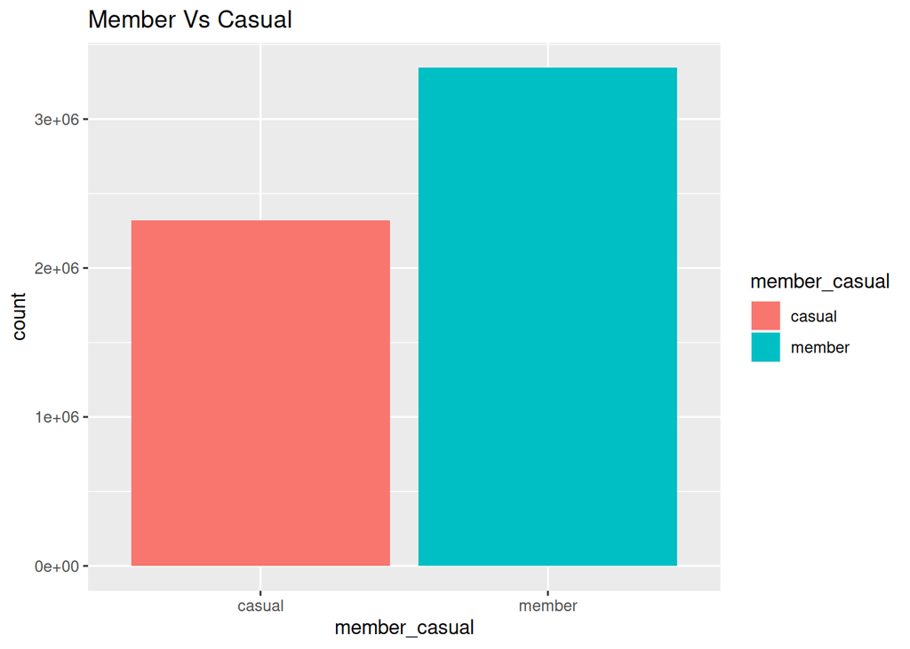

```r
ggplot(data = clean_data, mapping = aes(x=member_casual,fill=member_casual)) + geom_bar()+labs(title="Member Vs Casual")
```

There are 44% more membership rides as compared to casual members rides.

*Ride Analysis*

```r
cat("Average duration of rides is : ", mean(clean_data$ride_duration), "mins")
```

```
## Average duration of rides is :  19.44743 mins
```

```r
cat("Maximum ride duration is : ", round(max(clean_data$ride_duration)/60/24), "days")
```

```
## Maximum ride duration is :  29 days
```

```r
cat("Minimum duration of ride is : ", min(clean_data$ride_duration)*60, "sec")
```

```
## Minimum duration of ride is :  1 sec
```

*Ride differences between members and casual riders*

```r
avg_ride_duration <- clean_data %>%
  group_by(member_casual) %>%
  summarise(avg_ride_length = mean(ride_duration))

avg_ride_duration
```

```
## # A tibble: 2 × 2
##   member_casual avg_ride_length
##   <chr>         <drtn>
## 1 casual        29.14833 mins
## 2 member        12.71486 mins
```

```
## Defaulting to continuous.
```

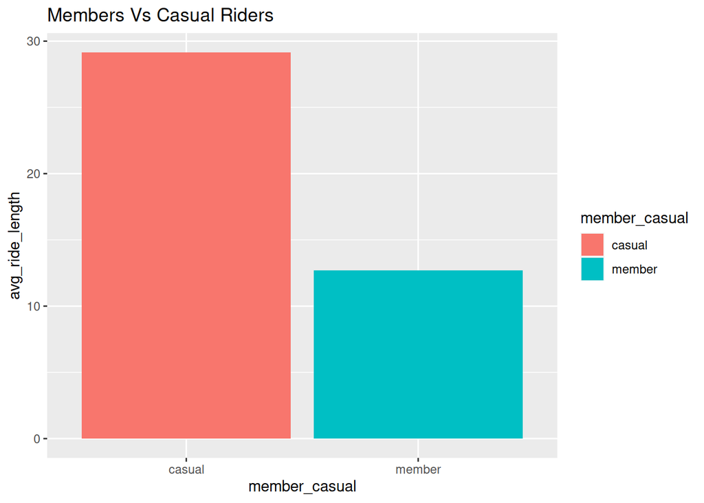

```r
ggplot(avg_ride_duration, aes(x=member_casual, y=avg_ride_length, fill=member_casual)) + geom_col() + labs(title="Members Vs Casual Riders")
```

*Comparing Bikes*

```r
clean_data %>%
  group_by(rideable_type) %>%
  summarise(rides=n()) %>%
  mutate(percent=rides*100/sum(rides))
```

```
## # A tibble: 3 × 3
##   rideable_type   rides percent
##   <chr>           <int>   <dbl>
## 1 classic_bike  2601088   45.9
## 2 docked_bike    177468    3.13
## 3 electric_bike 2888630   51.0
```

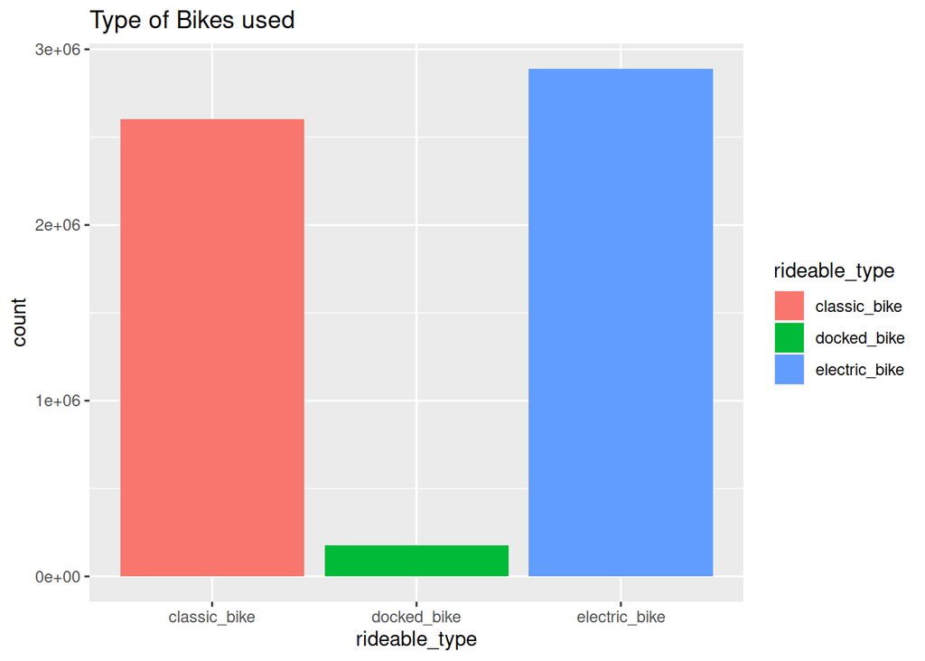

```r
ggplot(clean_data, aes(x=rideable_type, fill=rideable_type)) + geom_bar() + labs(title="Type of Bikes used")
```

Overall there is more demand for electric bikes

```r
member_type <- clean_data%>%
  group_by(member_casual, rideable_type)%>%
  summarise(rides=n())%>%
  mutate(percent=rides*100/sum(rides))
member_type
```

```
## # A tibble: 5 × 4
## # Groups:   member_casual [2]
##   member_casual rideable_type   rides percent
##   <chr>         <chr>           <int>   <dbl>
## 1 casual        classic_bike   891406   38.4
## 2 casual        docked_bike    177468    7.64
## 3 casual        electric_bike 1252895   54.0
## 4 member        classic_bike  1709682   51.1
## 5 member        electric_bike 1635735   48.9
```

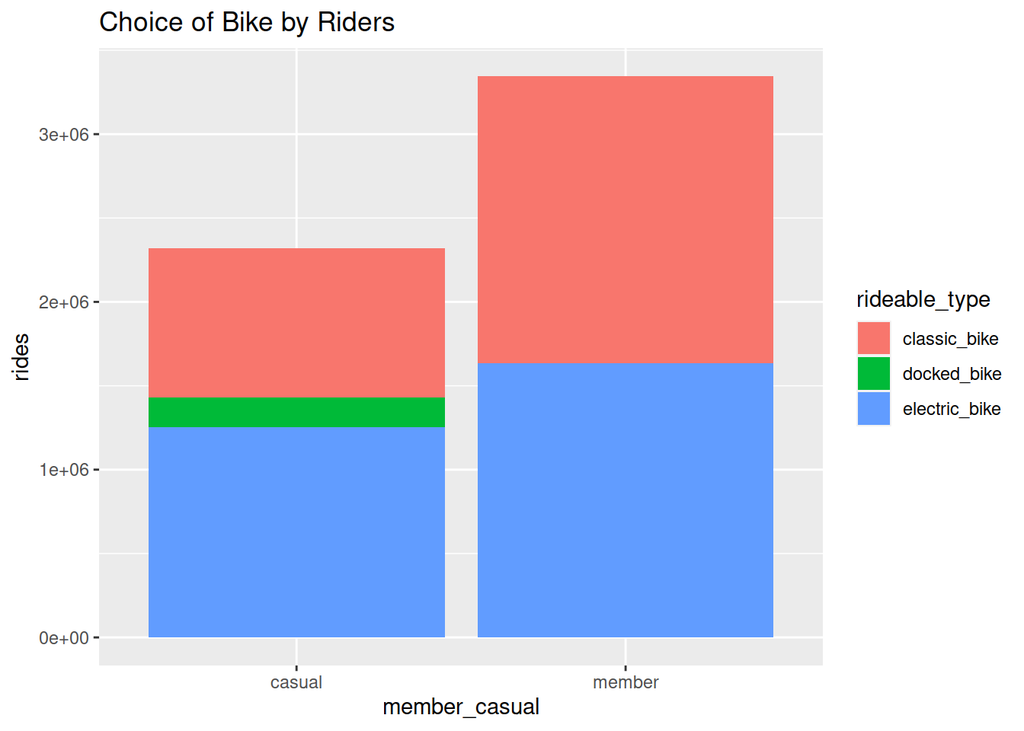

```r
ggplot(as.data.frame(member_type), aes(x=member_casual, y=rides, fill=rideable_type)) +
  geom_bar(stat='identity') + labs(title="Choice of Bike by Riders")
```

*Usage of bikes on different days*

```r
clean_data$weekday <- factor(clean_data$weekday, levels=c("Monday","Tuesday","Wednesday","Thursday","Friday","Saturday","Sunday"))
weektable <- clean_data %>%
  group_by(member_casual,weekday)%>%
  summarise(rides=n())%>%
  mutate(percent=rides*100/sum(rides))
weektable
```

```
## # A tibble: 14 × 4
## # Groups:   member_casual [2]
##    member_casual weekday    rides percent
##    <chr>         <fct>      <int>   <dbl>
##  1 casual        Monday    277649    12.0
##  2 casual        Tuesday   263706    11.4
##  3 casual        Wednesday 274339    11.8
##  4 casual        Thursday  309297    13.3
##  5 casual        Friday    334667    14.4
##  6 casual        Saturday  473130    20.4
##  7 casual        Sunday    388981    16.8
##  8 member        Monday    473305    14.1
##  9 member        Tuesday   518584    15.5
## 10 member        Wednesday 523836    15.7
## 11 member        Thursday  532215    15.9
## 12 member        Friday    467051    14.0
## 13 member        Saturday  443246    13.2
## 14 member        Sunday    387180    11.6
```

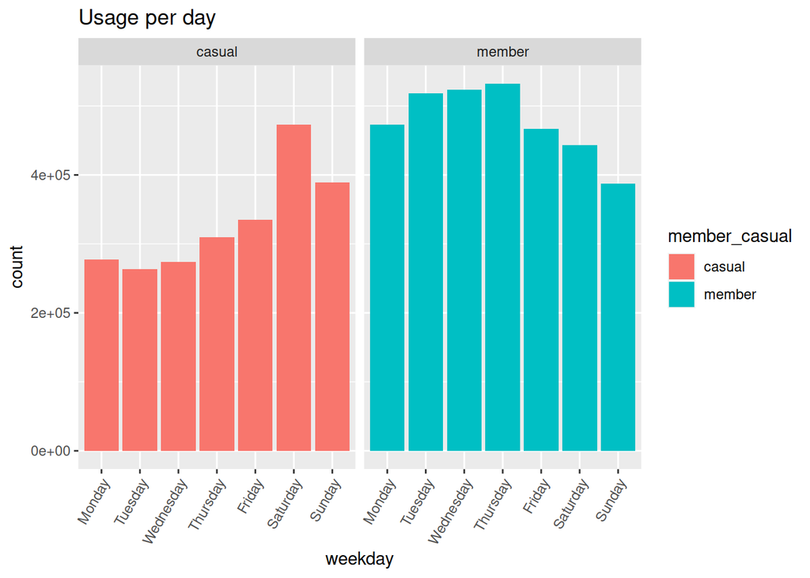

```r
ggplot(clean_data,aes(x=weekday, fill=member_casual)) + geom_bar() + facet_wrap(~member_casual)+theme(axis.text.x = element_text(angle=60, hjust=1)) + labs(title="Usage per day")
```

*Usage of bikes (Monthly)*

```r
month_table <- clean_data %>%
  group_by(member_casual, month_data) %>%
  summarise(rides=n()) %>%
  mutate(percent = rides*100/sum(rides))
month_table
```

```
## # A tibble: 24 × 4
## # Groups:   member_casual [2]
##    member_casual month_data  rides percent
##    <chr>              <int>  <int>   <dbl>
##  1 casual                 1  18517   0.798
##  2 casual                 2  21414   0.922
##  3 casual                 3  89874   3.87
##  4 casual                 4 126398   5.44
##  5 casual                 5 280387  12.1
##  6 casual                 6 369022  15.9
##  7 casual                 7 406013  17.5
##  8 casual                 8 358886  15.5
##  9 casual                 9 296664  12.8
## 10 casual                10 208961   9.00
## # ℹ 14 more rows
```

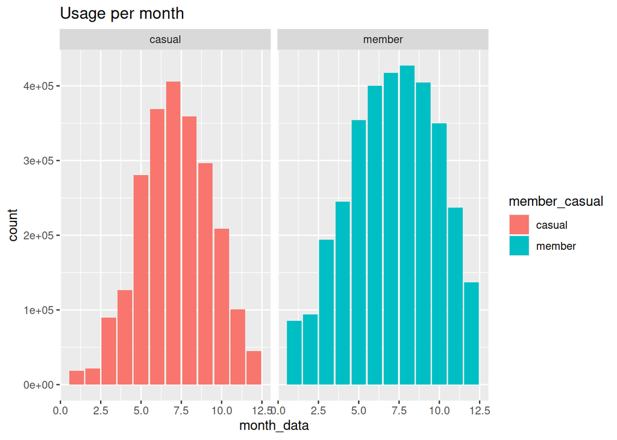

```r
ggplot(clean_data, aes(x=month_data, fill=member_casual)) + geom_bar() + facet_wrap(~member_casual) + labs(title="Usage per month")
```

### Findings

- About 60% rides are by members.
- Ride duration of Casual riders is much greater than members.
- Electric bikes are preferred more followed by classic bikes.
- Their is 50% increase in usage of bikes by casual riders in weekends especially on Saturday.
- Members usage is quite similar throughout the week days, a little drop is seen in weekends.
- Starting from March bike usage increases and peaks in July-August, and gradually decreases. Maybe due to weather conditions.